# Project 1 - Activity Monitoring

Raw data downloaded from https://d396qusza40orc.cloudfront.net/repdata%2Fdata%2Factivity.zip on Saturday, August 9, 2014 at 20:55pm

```r
setwd("/Users/pesto/Documents/school/coursera/rr/proj1")
adm<-read.csv("activity.csv")
```

**What is mean total number of steps taken per day?** For this part of the assignment, you can ignore the missing values in the dataset. Make a histogram of the total number of steps taken each day

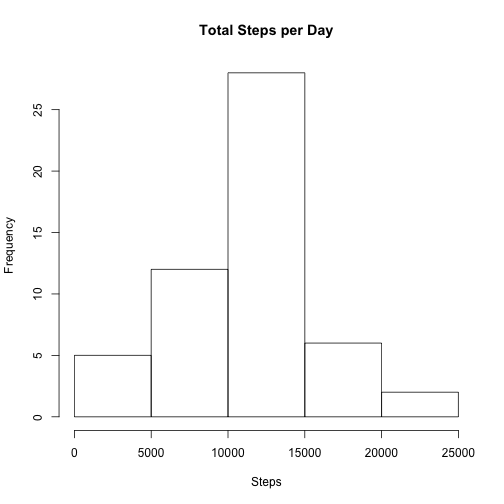

```r
admStepsPerDay<-data.frame(aggregate(steps ~ date, data=adm, sum))
hist(admStepsPerDay$steps,xlab="Steps",main="Total Steps per Day")
```

```r
admMeanStepsPerDay<-data.frame(aggregate(steps ~ date, data=adm, mean))
print(admMeanStepsPerDay)
```

```
##          date   steps
## 1  2012-10-02  0.4375
## 2  2012-10-03 39.4167
## 3  2012-10-04 42.0694
## 4  2012-10-05 46.1597
## 5  2012-10-06 53.5417
## 6  2012-10-07 38.2465
## 7  2012-10-09 44.4826
## 8  2012-10-10 34.3750
## 9  2012-10-11 35.7778
## 10 2012-10-12 60.3542
## 11 2012-10-13 43.1458
## 12 2012-10-14 52.4236
## 13 2012-10-15 35.2049
## 14 2012-10-16 52.3750
```

[output cut: 39 more lines]

**What is the average daily activity pattern?** Make a time series plot (i.e. type = “l”) of the 5-minute interval (x-axis) and the average number of steps taken, averaged across all days (y-axis)

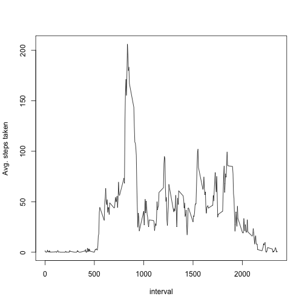

```r
admIS<-data.frame(aggregate(steps~interval, data=adm,mean))
with(admIS,(plot(steps~interval,type="l",pch=22,ylab="Avg. steps taken")))
```

Which 5-minute interval, on average across all the days in the dataset, contains the maximum number of steps?

```r
admIS[admIS$interval==max(admIS$interval),]
```

[output not shown]

**Imputing missing values** Note that there are a number of days/intervals where there are missing values (coded as NA). The presence of missing days may introduce bias into some calculations or summaries of the data. Calculate and report the total number of missing values in the dataset (i.e. the total number of rows with NAs)

The following code is correct. NAs only appear in sum() column. See sum(is.na(adm$date)) and sum(is.na(adm$interval))

```r
sum(is.na(adm))
```

```
## [1] 2304
```

Devise a strategy for filling in all of the missing values in the dataset. The strategy does not need to be sophisticated. For example, you could use the mean/median for that day, or the mean for that 5-minute interval, etc.

```r
tadm<-adm
tadm$steps[is.na(tadm$steps)]<-mean(tadm$steps)
```

Steps per day.

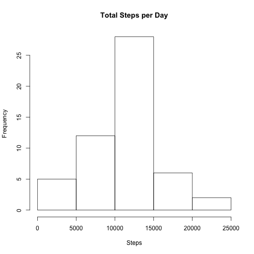

```r
tadmStepsPerDay<-data.frame(aggregate(steps ~ date, data=tadm, sum))
hist(tadmStepsPerDay$steps,xlab="Steps",main="Total Steps per Day")
```

Mean steps per day

```r
tadmMeanStepsPerDay<-data.frame(aggregate(steps ~ date, data=tadm, mean))
print(tadmMeanStepsPerDay)
```

```
##          date   steps
## 1  2012-10-02  0.4375
## 2  2012-10-03 39.4167
## 3  2012-10-04 42.0694
## 4  2012-10-05 46.1597
## 5  2012-10-06 53.5417
## 6  2012-10-07 38.2465
## 7  2012-10-09 44.4826
## 8  2012-10-10 34.3750
## 9  2012-10-11 35.7778
## 10 2012-10-12 60.3542
## 11 2012-10-13 43.1458
## 12 2012-10-14 52.4236
## 13 2012-10-15 35.2049
## 14 2012-10-16 52.3750
```

[output cut: 39 more lines]

Median steps per day

```r
tadmMedStepsPerDay<-data.frame(aggregate(steps ~ date, data=tadm, median))
print(tadmMedStepsPerDay)
```

```
##          date steps
## 1  2012-10-02     0
## 2  2012-10-03     0
## 3  2012-10-04     0
## 4  2012-10-05     0
## 5  2012-10-06     0
## 6  2012-10-07     0
## 7  2012-10-09     0
## 8  2012-10-10     0
## 9  2012-10-11     0
## 10 2012-10-12     0
## 11 2012-10-13     0
## 12 2012-10-14     0
## 13 2012-10-15     0
## 14 2012-10-16     0
```

[output cut: 39 more lines]

**Are there differences in activity patterns between weekdays and weekends?** Create a new factor variable with two levels, weekday and weekend indicating whether a given date is on a weekend or weekday

```r
adm$date<-as.Date(adm$date)
adm$day<-weekdays(as.Date(adm$date))
adm$wday[adm$day=="Sunday"]<-"weekend"
adm$wday[adm$day=="Saturday"]<-"weekend"
adm$wday[is.na(adm$wday)]<-"weekday"
adm$wday<-factor(adm$wday,levels=c("weekday","weekend"))
wdaydf<-as.data.frame(adm[adm$wday=="weekday",])
wenddf<-as.data.frame(adm[adm$wday=="weekend",])
wdayagdf<-aggregate(steps ~ interval, data=wdaydf,mean)
wendagdf<-aggregate(steps ~ interval, data=wenddf,mean)
```

```r
par(mfrow=c(2,1))
with(wendagdf,(plot(steps~interval,type="l",pch=22,ylab="Number of steps", main="weekend")))
```

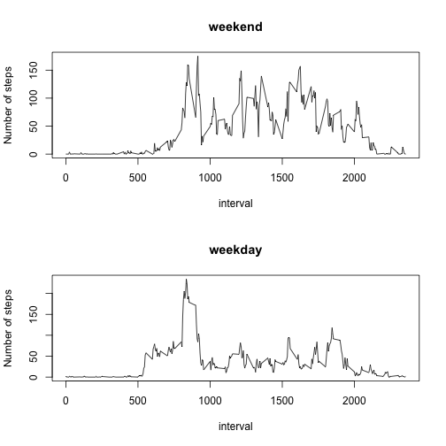

```r
with(wdayagdf,(plot(steps~interval,type="l",pch=22,ylab="Number of steps", main="weekday")))
```